# Prop Bet - LeBron James

Ken Marciel

7/22/2021

## Packages

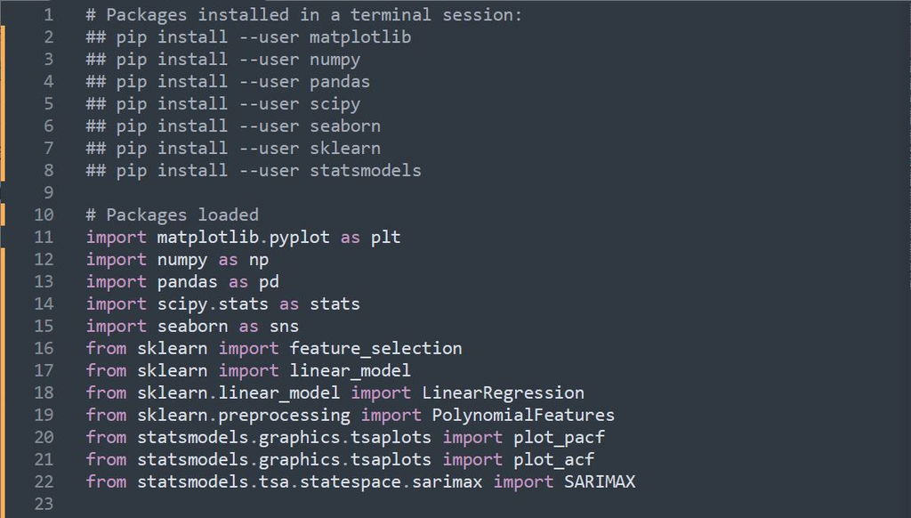

## 1. Data Collection

Data was collected from the website, Basketball-Reference.com, by Sports Reference. The data set consists of all the games played by LeBron James in the most recent season. This includes the 2020-2021 regular season and the six games played by in the 2021 playoffs, downloaded as two Excel files, respectively. Using Excel, the files were converted to CSV files. These were then read into Python. The subsets of all games that LeBron James played in were concatenated to exclude the games in which he was inactive. The index of the new file was renumbered from 0 to 50, for the 51 games that LeBron James played in for 2020-2021 regular season and playoffs.

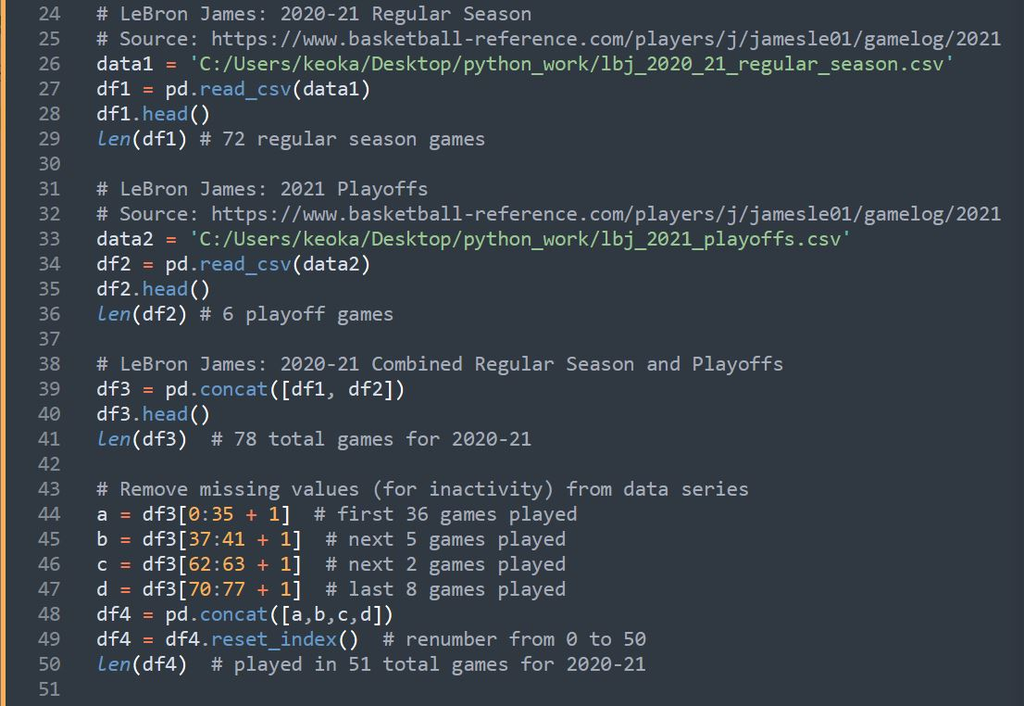